# Assignment_9

Trevor D. Millar

10/28/2020

## Introduction

For this assignment, we will be carrying out an analysis of grad school admissions data. The variables included in the data set are GPA, GRE score, and school rank. The purpose of this anaylsis will be to determine each variables effect on probability of being accepted into a graduate school program.

## Loading and cleaing the data

The data for the graduate school admissions statistics are loaded into R and saved as a dataframe named “df”. The data are ‘cleaned’ by changing the column of admits from 0s and 1s to FALSE and TRUE respectively. The data are further cleaned by changing the integer values of rank to ‘factor’ data types for use in the analysis (these are non-continuous data).

```r
library(tidyverse)
library(modelr)
library(MASS)
library(patchwork)

df <- read_csv("../../Data/GradSchool_Admissions.csv")


df$admit <- as.logical(df$admit)
df$rank <- as.factor(df$rank)

names(df)
```

```
## [1] "admit" "gre"   "gpa"   "rank"
```

## Analysis

Here, we make as accurate a model as is possible given the data we have. First, we create the model (using different variables to attempt to find any correlations with the data), then we calculate the mean square residual value as a proxy for the accuracy of the model to the true data. The model with the lowest mean square residual value is chosen to model our data.

```r
mod_GPA <- glm(data = df,admit ~ gpa, family = "binomial")
print("Mean square residuals of the model based on GPA:")
```

```
## [1] "Mean square residuals of the model based on GPA:"
```

```r
mean(mod_GPA$residuals^2)
```

```
## [1] 4.937191
```

```r
mod_GRE <- glm(data = df,admit ~ gre, family = "binomial")
print("Mean square residuals of the model based on GRE:")
```

```
## [1] "Mean square residuals of the model based on GRE:"
```

```r
mean(mod_GRE$residuals^2)
```

```
## [1] 4.873917
```

```r
mod_RANK <- glm(data = df,admit ~ rank, family = "binomial")
print("Mean square residuals of the model based on Rank:")
```

```
## [1] "Mean square residuals of the model based on Rank:"
```

```r
mean(mod_RANK$residuals^2)
```

```
## [1] 5.097444
```

```r
mod_full <- glm(data = df,admit ~ gpa + gre + rank, family = "binomial")
mod_RANK <- glm(data = df,admit ~ rank, family = "binomial")
print("Mean square residuals of the model based on all factors:")
```

```
## [1] "Mean square residuals of the model based on all factors:"
```

```r
mean(mod_full$residuals^2)
```

```
## [1] 5.419835
```

```r
mod_full_w_interactions <- glm(data = df,admit ~ gpa * gre * rank, family = "binomial")
print("Mean square residuals of the model based on all factors and their interactions:")
```

```
## [1] "Mean square residuals of the model based on all factors and their interactions:"
```

```r
mean(mod_full_w_interactions$residuals^2)
```

```
## [1] 5.330803
```

It looks like the “best” model (based on mean square residuals) to this point is admissions as a function of GRE score. Let’s see if we can optimize a more comprehensive model.

```r
step <- stepAIC(mod_full_w_interactions)
```

```
## Start:  AIC=482.39
## admit ~ gpa * gre * rank
##
##                Df Deviance    AIC
## - gpa:gre:rank  3   454.54 480.54
## <none>              450.39 482.39
##
## Step:  AIC=480.54
## admit ~ gpa + gre + rank + gpa:gre + gpa:rank + gre:rank
##
##            Df Deviance    AIC
## - gpa:rank  3   455.25 475.25
## - gre:rank  3   455.28 475.28
## <none>          454.54 480.54
## - gpa:gre   1   457.73 481.73
##
## Step:  AIC=475.25
## admit ~ gpa + gre + rank + gpa:gre + gre:rank
##
##            Df Deviance    AIC
## - gre:rank  3   455.77 469.77
## <none>          455.25 475.25
## - gpa:gre   1   458.24 476.24
##
## Step:  AIC=469.77
## admit ~ gpa + gre + rank + gpa:gre
##
##           Df Deviance    AIC
## <none>         455.77 469.77
## - gpa:gre  1   458.52 470.52
## - rank     3   477.85 485.85
```

```r
print("Formula for the optimized model:")
```

```
## [1] "Formula for the optimized model:"
```

```r
step$formula
```

```
## admit ~ gpa + gre + rank + gpa:gre
```

```r
mod_step <- glm(data = df, formula = step$formula)
print("Mean square residiuals of our optimized model:")
```

```
## [1] "Mean square residiuals of our optimized model:"
```

```r
mean(mod_step$residuals)
```

```
## [1] 1.949996e-15
```

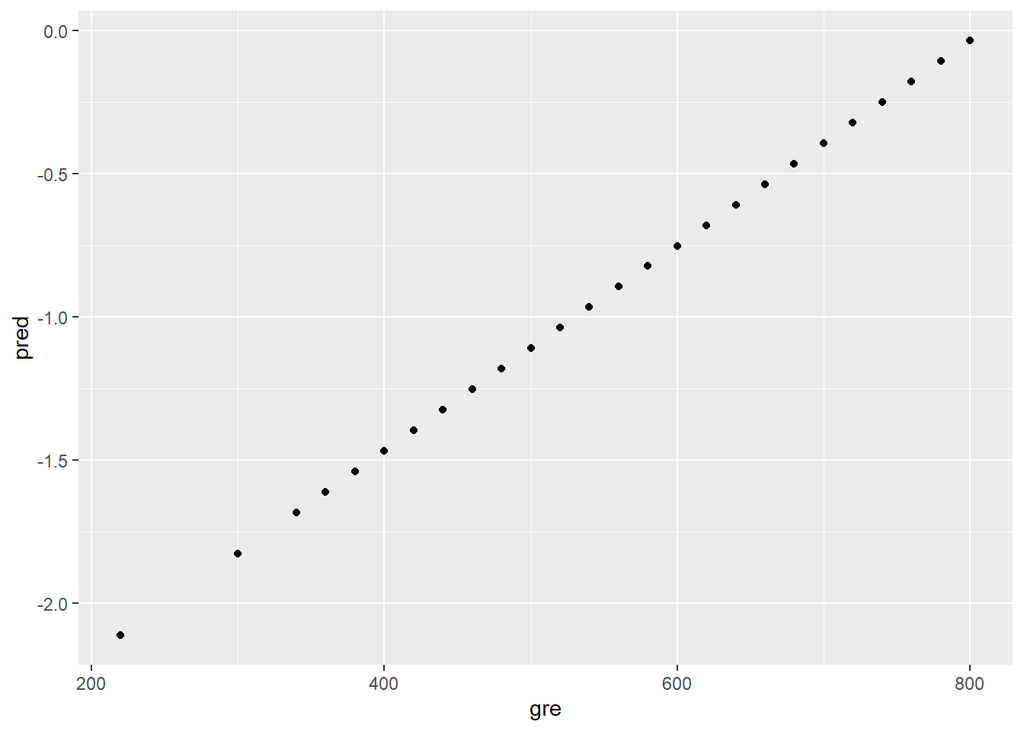

```r
df_pred <- add_predictions(df, mod_GRE)
ggplot(df_pred, aes(x = gre, y = pred))+
  geom_point()
```

In the graph above, one very apparent issue arises. Because there is only one variable to create predictions with, we end up with a basic linear formula (y = mx + b). Because of this, all of our predictions end up in a straight line. This is (obviously), not the type of model we want because in real life we can not have a negative probability of being accepted into graduate school no matter how terrible students we are.

Lets take a look at the summary of our comprehensive model and see which variables are significant. An * indicates a statistically significant variable.

```r
summary(mod_full_w_interactions)
```

```
##
## Call:
## glm(formula = admit ~ gpa * gre * rank, family = "binomial",
##     data = df)
##
## Deviance Residuals:
##     Min       1Q   Median       3Q      Max
## -1.7664  -0.8518  -0.6437   1.0565   2.2283
##
## Coefficients:
##                 Estimate Std. Error z value Pr(>|z|)
## (Intercept)   -35.999967  16.048971  -2.243   0.0249 *
## gpa            10.242737   4.716620   2.172   0.0299 *
## gre             0.052274   0.025176   2.076   0.0379 *
## rank2          33.954685  18.430800   1.842   0.0654 .
## rank3          14.608867  20.838126   0.701   0.4833
## rank4          13.935601  24.587935   0.567   0.5709
## gpa:gre        -0.014640   0.007294  -2.007   0.0447 *
## gpa:rank2     -10.105436   5.447632  -1.855   0.0636 .
## gpa:rank3      -4.978875   6.062873  -0.821   0.4115
## gpa:rank4      -4.666198   7.120462  -0.655   0.5123
## gre:rank2      -0.054299   0.029213  -1.859   0.0631 .
## gre:rank3      -0.020111   0.033741  -0.596   0.5511
## gre:rank4      -0.023092   0.040135  -0.575   0.5651
## gpa:gre:rank2   0.015725   0.008524   1.845   0.0651 .
## gpa:gre:rank3   0.006381   0.009675   0.659   0.5096
## gpa:gre:rank4   0.006888   0.011536   0.597   0.5505
## ---
## Signif. codes:  0 '***' 0.001 '**' 0.01 '*' 0.05 '.' 0.1 ' ' 1
##
## (Dispersion parameter for binomial family taken to be 1)
##
##     Null deviance: 499.98  on 399  degrees of freedom
## Residual deviance: 450.39  on 384  degrees of freedom
## AIC: 482.39
##
## Number of Fisher Scoring iterations: 5
```

Our optimized model is using every statistically significant variable and interaction. This model follows the following formula: admit ~ gpa + gre + rank + gpa:gre, where gpa:gre is the interaction of those two variables. It is important that our model show all of the statistically significant variables and interactions, without becoming excessively complex. Our optimized model is accurate without being overly complex.

Let’s make a few graphs of our model.

## Graphs

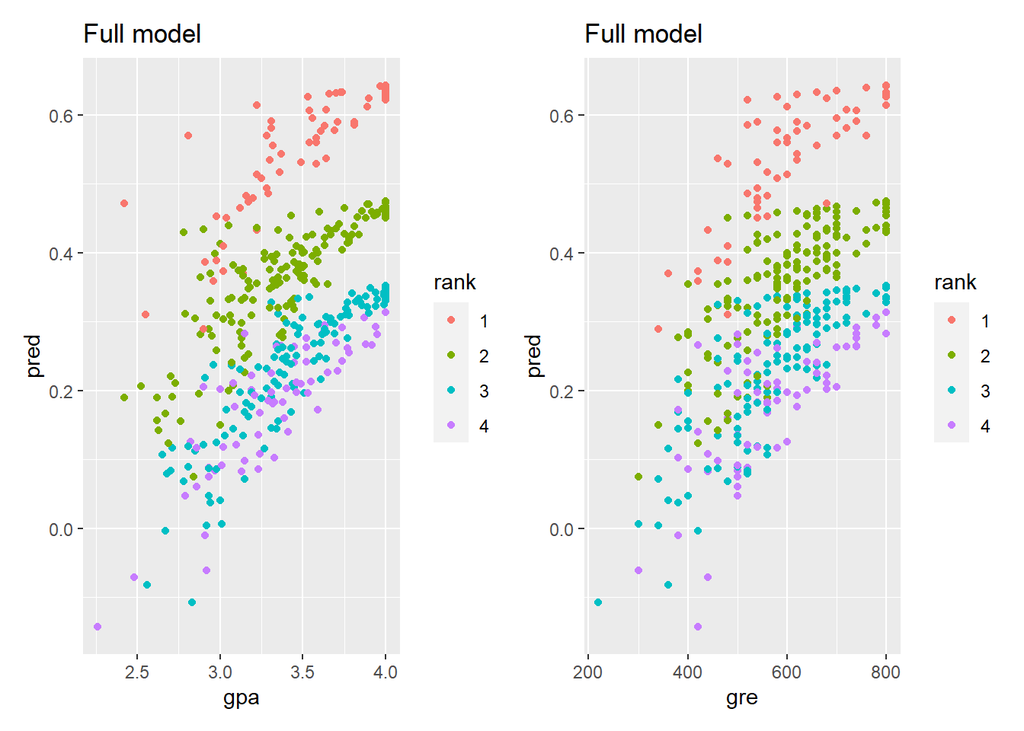

```r
df_pred_full <- add_predictions(df, mod_step)
p_full_gre <- ggplot(df_pred_full, aes(x = gre, y= pred, color = rank))+
  ggtitle("Full model")+
  geom_point()
p_full_gpa <- ggplot(df_pred_full, aes(x = gpa, y= pred, color = rank))+
  ggtitle("Full model")+
  geom_point()

p_full_gpa + p_full_gre
```

## Conclusions of our analysis

In summary, what we can learn from this data set are the following conclusions:

1. Go to the best undergraduate institution you can. Even if your GPA isn’t as good as it would be in other programs, you will still have a better shot at getting to grad school.
2. Study hard for the GRE. Your GRE school is one of the pillars of your acceptance into graduate school.
3. Work hard to get good grades in your undergraduate program, although the reputation of your school and your GRE score may both out - weigh your GPA.